# Nigeria Data Health Survey Analysis

A look into the effect on Govt Policy in Nigeria Population Growth

Ian Zablon Owuor

2024-10-31

Over the past few years, Nigeria has recorded one of the highest increase in population not only in Africa but in the whole world. An increase in population leads to an increase in the workforce of a country there-by causing an increase in the Gross Domestic Production. In as much as a positive increase in the population causes an increase in GDP, Population increase also comes with its own share of challenges. Nigeria as a country has recorded an increased population over the years and as at 2023, the population of Nigeria is 233.8 million people. By 2050, the Nigerian population is expected to double and by 2100, Nigeria’s population will jump to 791 million, overtaking Chinaa to become the second-most populous country in the world after only India. This is something that can’t be neglected as more than 80 million Nigerians already live below the poverty line ( Okpala, A. O.9(4), 63-77. ) The Federal Government of Nigeria has taken steps to ensure that the population growth rate of Nigeria is dealt with. The minister of health Osagie Ehanire said that one of the strategies that the Federal Government has employed to curb the fast rate of population growth is the development of a Task-Shifting/Task-sharing policy which seeks to achieve rational redistribution of clinical and other tasks among healthcare workers that will ensure an increase access to family planning and sexual and reproductive health services especially to rural and hard-reach areas. Another policy that was adopted by the Federal Government of Nigeria is the reduction in the fertility from the levels back then which were at 6 children/family to an average of 4 children/family. It also suggested that the optimum marriage age should be 18 years for women and 24 years for men and advocated that the pregnancies be limited to women between the age of 18-35 year range at an interval of 2 years (Mazzocco, K.9(3), 1-12.) Finally the Federal Government of Nigeria decided to increase the awareness of its people through mass media forms particularly through radio to educate the population about the need for family planning and maternal child health programs. In this analysis we look at if and how these policies have been fulfilled in the step to ensuring that the birth rate of Nigeria is put under control.

## 1 **Question 1.1**

### 1.1 **Research question 1.1**

The Nigerian Federal Government has put policies to reduce the fast increase in the population growth. Have these policies adopted by the Federal Government of Nigeria helped to reduce the population growth rate in the Country?. Some of the reasons that might have caused an increase in population include. • Drop in the age of marriage for women has led to increase in birth rate. • Reduction in the pregnancy age (< 18) and older women (> 35) getting pregnant. • Poor public education by mass media particularly radio. • High illiteracy levels. • Religious beliefs that encourage early birth in women. • Low levels of higher education.

### 1.2 **Research question 1.2**

**How does your research Question pertain to public policy.**

**1. Population Control Policies**: The research question directly addresses the effectiveness of pop ulation control policies implemented by the Federal Government of Nigeria. These policies are of significant public interest and are aimed at managing the country’s demographic growth. **2. Healthcare and Reproductive Services**: The policies are related to healthcare services, especially family planning and maternal health. They influence the availability and accessibility of such services to the public, particularly women and families. **3. Education and Awareness:** The research question touches on the impact of public education efforts through mass media, such as radio. It evaluates the role of education and awareness campaigns in shaping reproductive behavior.

• Who are the primary Stakeholders or groups affected by this issue?

**1. The Nigerian Government**: The government plays a central role in designing, implementing, and monitoring population control policies. It is invested in the outcomes of these policies to achieve demographic and economic goals. **2. Healthcare Providers:** Health workers and organizations are essential stakeholders as they deliver family planning and reproductive health services. Their workload may be affected by changes in reproductive behavior. **3. Women and Families:** Women of childbearing age, couples, and families are directly affected by the policies that may influence their reproductive decisions. **4. Religious and Cultural Institutions:** These institutions can play a role in shaping cultural norms and beliefs about family planning and childbirth. **5. Mass Media Organizations:** Radio and other mass media outlets are involved in disseminating information about family planning and reproductive health. They have a role in educating the public.

• In what ways can understanding or addressing this issue influence policy decisions or outcomes?

**1. Policy Evaluation:** The research can provide evidence-based insights into the effectiveness of existing policies. If the policies are found to be successful, this can reinforce their continuation. If they are ineffective, it may lead to policy adjustments or the development of new strategies. **2. Resource Allocation:** The findings can guide the allocation of resources to healthcare, education, and awareness campaigns. Policymakers can prioritize investments in areas that have a more significant impact on reducing birth rates. **3. Public Awareness:** Understanding the role of mass media in shaping reproductive behavior can lead to more targeted and effective public awareness campaigns. This can improve access to information about family planning and maternal health. **4. Cultural and Religious Sensitivity:** Policymakers may need to consider cultural and religious beliefs when designing and implementing policies. This research can shed light on how these factors influence reproductive choices. **5. Gender Equality and Education:** If a drop in the age of marriage for women or high illiteracy levels is identified as a driver of population growth, policies promoting gender equality and education may be more strongly emphasized.

### 1.3 **Question 1.3**

**Personal Reflection.**

• Share a bit of your perspective or experiences that led you to this research question. My major concern for this research was the sustainable development for Nigeria. The increase in population in Nigeria has had significant environmental, social and economic impact making access to basic health services, jobs and employment hard to come by.

•Why does this questionn resonates with you personally and what drove your interest to explore it further. My personal motivation to explore this question further was driven by the desire to contribute to more informed policy decisions, advocate for change and better understand the complex factors that play in population growth in Nigeria.

## 2 **Graded Task 2: Exploration**

The Demographic and Health Surveys (DHS) is a series of standardized surveys conducted periodically in developing countries that includes collecting data on various aspects of population, health, and nutrition.These surveys are a gold-standard source of reliable public health data for many countries and international bodies.

Several datasets (called recodes) are made available from each survey, including a household recode, men’s recode and the women’s recode (sometimes called the individual recode). This individual recode dataset contains individual-level data on women aged 15 to 49 in the surveyed.

### 2.1 Load the required Packages.

```r
# Load packages
 if(!require("pacman")) install.packages("pacman")
 ## Loading required package: pacman
 3
```

```
## [1] 3
```

```r
pacman::p_load(
 here,# forcermdstousetheprojectfolderasworkingdirectory
 haven,#forreadinginstatafiles
 tidyverse,#foreverything!
 here
 )
```

First, I download the dataset from the Demographic and Health Survey(DHS)website.

### 2.2 Question2.1

- Write code below to load your data.

The dataset from DHS comes in theform of a .DTA file (the main data file in STATA format).To import the DHS data set from the. DTA format into R I use the read_dta() function from the {haven} package.

DHS files can be quite large–the Nigeria 2018 data has over 40,000 rows and 5,000columns. To avoid loading all the columns that may end up taking too long to load, I use the col_select arguement of the read_dta() to specify which columns to import for the analysis.

The columns that we want for the analysis include(age, location, education, etc). To check which columns to pick ,there is a data dictionary in the data folder in the project that explains what each variables mean.

```r
#Readingin the.dtafile
ir_raw <-
  haven::read_dta(here("data/NGIR7BFL.DTA"),
 col_select= c(
 #basicinformation
 v006,v007,v009,v010,v012,v013,
 v022,v024,v025,v106,v130,v190,
 #fertility,reproductivetiming,literacylevelandmedia
 v201,v212,v213,v511,v531,
 v213,v158,v302,v155))
```

Since the DHS variable names are not very descriptive (like v000 and v001),we will use rename() to give them short, descriptive titles.

```r
#Renaming thevariables
 ir_renamed <-
  ir_raw%>%
  rename(
    Mth_interview= v006,
    Yr_interview= v007,
    Mth_birth= v009,
    Yr_birth= v010,
    Age= v012,
    Age_group= v013,
    State= v022,
    Region= v024,
    Urban_rural= v025,
    Highest_educ= v106,
    Religion= v130,
    Wealth_index= v190,
    Num_kids= v201,
    Age_first_birth= v212,
    Curr_pregnant = v213,
    Age_first_cohabitation = v511,
    Age_first_sex = v531,
    Currently_pregnant = v213,
    Listen_radio = v158,
    Ever_used_contraceptive = v302,
    Literacy = v155)
```

### 2.3 Question 2.2

- Use the colnames() to display the column names of your data set.

```r
colnames(ir_renamed)
```

```
##  [1] "Mth_interview"           "Yr_interview"
##  [3] "Mth_birth"               "Yr_birth"
##  [5] "Age"                     "Age_group"
##  [7] "State"                   "Region"
##  [9] "Urban_rural"             "Highest_educ"
## [11] "Religion"                "Literacy"
## [13] "Listen_radio"            "Wealth_index"
## [15] "Num_kids"                "Age_first_birth"
## [17] "Currently_pregnant"      "Ever_used_contraceptive"
## [19] "Age_first_cohabitation"  "Age_first_sex"
```

- Explain what the columns represent.

This data set contains 20 columns. The “Mth_interview” column represents the monththe interview was carried out, “Yr_interview”representst the year the interviewwas carried out, “Mth_birth” represent the month to which the respondent was born, “Yr_birth” represent the year to which the respondent was born, “Age” represent the age of the respondent, “Age_group” is the age group of the respondent, “State” represent the state where the respodent lives in “Region” represent the region where the respondent is from, “Urban_rural” represent the type of setting to which the respondent lives, “Highest_educ” represent the highest level of education that the respondent has attained, “Religion” represent the religion to which the respondent is af filiated to, “Literacy”represents wether the respondent can read/write on not, “Listen_radio” represent the frequency to which the respondents listens to radio, “Wealth_index” represents the level of wealth of the respondents, “Num_kids” represents the total number of children in a particular household, “Age_first_birth” represents the age to which the respondent had first child, “Currently_pregnant” represents wether the respondent is expectant or not, “Ever_used_contraceptive” is a knowledge question if the respondent has ever used any form of contraceptive, “Age_first_cohabitation” represent the age at which the respondent was married then finally age at first sex represents the age a which the respondent had sex for the first time.

While importing the data the read_dta() function reads in factor data as a special data type called labelled data

**Review data types.**

```r
glimpse(ir_renamed)
```

```
## Rows: 41,821
## Columns: 20
## $ Mth_interview           <dbl> 9, 9, 9, 9, 9, 9, 9, 9, 9, 9, 9, 9, 9, 9, 9, 9…
## $ Yr_interview            <dbl> 2018, 2018, 2018, 2018, 2018, 2018, 2018, 2018…
## $ Mth_birth               <dbl> 3, 6, 5, 11, 5, 2, 7, 1, 4, 9, 12, 2, 9, 8, 5,…
## $ Yr_birth                <dbl> 1978, 2002, 1981, 1990, 1989, 1991, 1991, 1994…
## $ Age                     <dbl> 40, 16, 37, 27, 29, 27, 27, 24, 35, 35, 26, 15…
## $ Age_group               <dbl+lbl> 6, 1, 5, 3, 3, 3, 3, 2, 5, 5, 3, 1, 4, 6, …
## $ State                   <dbl+lbl> 1, 1, 1, 1, 1, 1, 1, 1, 1, 1, 1, 1, 1, 1, …
## $ Region                  <dbl+lbl> 1, 1, 1, 1, 1, 1, 1, 1, 1, 1, 1, 1, 1, 1, …
## $ Urban_rural             <dbl+lbl> 1, 1, 1, 1, 1, 1, 1, 1, 1, 1, 1, 1, 1, 1, …
## $ Highest_educ            <dbl+lbl> 3, 2, 3, 3, 2, 2, 2, 2, 0, 2, 2, 2, 3, 2, …
## $ Religion                <dbl+lbl> 2, 2, 1, 2, 2, 1, 2, 2, 1, 2, 2, 2, 1, 2, …
## $ Literacy                <dbl+lbl> 2, 2, 2, 2, 2, 0, 2, 2, 0, 2, 2, 2, 2, 2, …
## $ Listen_radio            <dbl+lbl> 2, 1, 2, 2, 2, 1, 2, 2, 0, 2, 2, 1, 2, 2, …
## $ Wealth_index            <dbl+lbl> 5, 5, 5, 5, 5, 5, 5, 5, 4, 5, 5, 5, 5, 3, …
## $ Num_kids                <dbl> 3, 0, 3, 1, 0, 1, 0, 1, 4, 0, 0, 0, 1, 2, 2, 1…
## $ Age_first_birth         <dbl> 22, NA, 28, 26, NA, 25, NA, 21, 20, NA, NA, NA…
## $ Currently_pregnant      <dbl+lbl> 0, 0, 0, 0, 0, 1, 0, 0, 0, 0, 0, 0, 0, 0, …
## $ Ever_used_contraceptive <dbl+lbl> NA, NA, NA, NA, NA, NA, NA, NA, NA, NA, NA…
## $ Age_first_cohabitation  <dbl> 21, NA, 28, 26, NA, 22, NA, 21, 18, NA, NA, NA…
## $ Age_first_sex           <dbl+lbl> 21,  0, 14, 17, 17, 10, 20, 15, 15, 18, 18…
```

Several variables are of class “dbl+lbl”. This means that the columns display only numbers, and each number corresponds to a survey answer. This is cryptic and can be problematic for later analysis, so we convert these to regular R factors using the function haven::as_factor(). This will replace the numbers with the corresponding text label.

```r
# convert the data from labelled data to regular factors.
ir_clean <-
  ir_renamed %>%
  haven::as_factor()
```

Now we can see that the variables that were previously “dbl+lbl” are now “fct” (factor) and the numbers are replaced with descriptive text.

```r
glimpse(ir_clean)
```

```
## Rows: 41,821
## Columns: 20
## $ Mth_interview           <dbl> 9, 9, 9, 9, 9, 9, 9, 9, 9, 9, 9, 9, 9, 9, 9, 9…
## $ Yr_interview            <dbl> 2018, 2018, 2018, 2018, 2018, 2018, 2018, 2018…
## $ Mth_birth               <dbl> 3, 6, 5, 11, 5, 2, 7, 1, 4, 9, 12, 2, 9, 8, 5,…
## $ Yr_birth                <dbl> 1978, 2002, 1981, 1990, 1989, 1991, 1991, 1994…
## $ Age                     <dbl> 40, 16, 37, 27, 29, 27, 27, 24, 35, 35, 26, 15…
## $ Age_group               <fct> 40-44, 15-19, 35-39, 25-29, 25-29, 25-29, 25-2…
## $ State                   <fct> nc benue urban, nc benue urban, nc benue urban…
## $ Region                  <fct> north central, north central, north central, n…
## $ Urban_rural             <fct> urban, urban, urban, urban, urban, urban, urba…
## $ Highest_educ            <fct> higher, secondary, higher, higher, secondary, …
## $ Religion                <fct> other christian, other christian, catholic, ot…
## $ Literacy                <fct> able to read whole sentence, able to read whol…
## $ Listen_radio            <fct> at least once a week, less than once a week, a…
## $ Wealth_index            <fct> richest, richest, richest, richest, richest, r…
## $ Num_kids                <dbl> 3, 0, 3, 1, 0, 1, 0, 1, 4, 0, 0, 0, 1, 2, 2, 1…
## $ Age_first_birth         <dbl> 22, NA, 28, 26, NA, 25, NA, 21, 20, NA, NA, NA…
## $ Currently_pregnant      <fct> no or unsure, no or unsure, no or unsure, no o…
## $ Ever_used_contraceptive <fct> NA, NA, NA, NA, NA, NA, NA, NA, NA, NA, NA, NA…
## $ Age_first_cohabitation  <dbl> 21, NA, 28, 26, NA, 22, NA, 21, 18, NA, NA, NA…
## $ Age_first_sex           <fct> 21, not had sex, 14, 17, 17, 10, 20, 15, 15, 1…
```

### 2.4 Question 2.3

- Work with the janitor package to clean columns names. The code below guide you through the process.

```r
library(janitor)
nigeria_clean <- clean_names(ir_clean)
```

- What transformations did the clean_names() function make to your data frame columns.

```r
colnames(nigeria_clean)
```

```
##  [1] "mth_interview"           "yr_interview"
##  [3] "mth_birth"               "yr_birth"
##  [5] "age"                     "age_group"
##  [7] "state"                   "region"
##  [9] "urban_rural"             "highest_educ"
## [11] "religion"                "literacy"
## [13] "listen_radio"            "wealth_index"
## [15] "num_kids"                "age_first_birth"
## [17] "currently_pregnant"      "ever_used_contraceptive"
## [19] "age_first_cohabitation"  "age_first_sex"
```

The clean_names() function from the janitor package helped in cleaning the column names by changing the letters from capital to small letters and adding an under-score fro easy analysis.

- In your opinion, were these changes beneficial to your analysis. Explain.

The changes made by the clean_names() functions were beneficial to the analysis project by changing the column names to names that are all in lower-case, adding underscore in the column names and removing spaces in the column names for easy manipulation.

### 2.5 Question 2.4

- 2.4 A) Begin by diving into the distribution of specific variable(s) across a time or a date element. Use the glimpse() function and point out the number of rows, some data types and columns in your data.

The glimpse() function in R is a convenient way to get a quick overview of the nigeria_clean data frame, showing the number of rows, data types, and a preview of columns. To dive into the distribution of a specific variable(s) across a time or date element,we use glimpse() function with the nigeria_clean dataset and focus on the relevant columns which are the num_kids and the yr_birth columns.

```r
#  Load the dplyr library for data manipulation.
library(dplyr)

# Use the glimpse() function to explore the data.
dplyr::glimpse(nigeria_clean)
```

```
## Rows: 41,821
## Columns: 20
## $ mth_interview           <dbl> 9, 9, 9, 9, 9, 9, 9, 9, 9, 9, 9, 9, 9, 9, 9, 9…
## $ yr_interview            <dbl> 2018, 2018, 2018, 2018, 2018, 2018, 2018, 2018…
## $ mth_birth               <dbl> 3, 6, 5, 11, 5, 2, 7, 1, 4, 9, 12, 2, 9, 8, 5,…
## $ yr_birth                <dbl> 1978, 2002, 1981, 1990, 1989, 1991, 1991, 1994…
## $ age                     <dbl> 40, 16, 37, 27, 29, 27, 27, 24, 35, 35, 26, 15…
## $ age_group               <fct> 40-44, 15-19, 35-39, 25-29, 25-29, 25-29, 25-2…
## $ state                   <fct> nc benue urban, nc benue urban, nc benue urban…
## $ region                  <fct> north central, north central, north central, n…
## $ urban_rural             <fct> urban, urban, urban, urban, urban, urban, urba…
## $ highest_educ            <fct> higher, secondary, higher, higher, secondary, …
## $ religion                <fct> other christian, other christian, catholic, ot…
## $ literacy                <fct> able to read whole sentence, able to read whol…
## $ listen_radio            <fct> at least once a week, less than once a week, a…
## $ wealth_index            <fct> richest, richest, richest, richest, richest, r…
## $ num_kids                <dbl> 3, 0, 3, 1, 0, 1, 0, 1, 4, 0, 0, 0, 1, 2, 2, 1…
## $ age_first_birth         <dbl> 22, NA, 28, 26, NA, 25, NA, 21, 20, NA, NA, NA…
## $ currently_pregnant      <fct> no or unsure, no or unsure, no or unsure, no o…
## $ ever_used_contraceptive <fct> NA, NA, NA, NA, NA, NA, NA, NA, NA, NA, NA, NA…
## $ age_first_cohabitation  <dbl> 21, NA, 28, 26, NA, 22, NA, 21, 18, NA, NA, NA…
## $ age_first_sex           <fct> 21, not had sex, 14, 17, 17, 10, 20, 15, 15, 1…
```

```r
# To focus on the distribution of the variable across mth_interview and yr_interview:
glimpse(select(nigeria_clean, num_kids, yr_birth))
```

```
## Rows: 41,821
## Columns: 2
## $ num_kids <dbl> 3, 0, 3, 1, 0, 1, 0, 1, 4, 0, 0, 0, 1, 2, 2, 1, 0, 1, 2, 3, 1…
## $ yr_birth <dbl> 1978, 2002, 1981, 1990, 1989, 1991, 1991, 1994, 1983, 1983, 1…
```

The nigeria_clean data frame has 20 columns with 41,821 rows. The data frame also consists of mainly two data types which are double and factors.

```r
summary(nigeria_clean$num_kids)
```

```
##    Min. 1st Qu.  Median    Mean 3rd Qu.    Max.
##    0.00    0.00    2.00    3.05    5.00   17.00
```

The summary() function shows the summary for the “num_kids” variable giving out the minimum value of number of kids variable, the 1st quantile, median, mean, third quantile and the maximum values.

- 2.4 B) Plot and analyze the distribution of a specific variable(s) across a time or a date element. Use the layers/geoms from ggplot2 to visualize your findings. You may create 2 graphs or 1 graph and a summarized table where you calculate relevant statistics. You must include a minimun a title, the data sourse and clean up your legend, X and Y axis in a professional and visually pleasing manner.

The variables that I will plot for this visualization is the yr_birth and fill against two other variables i.e “currently_pregnant” for the pregnancy status and “literacy” ability of the respondent to read part or full sentence or not.

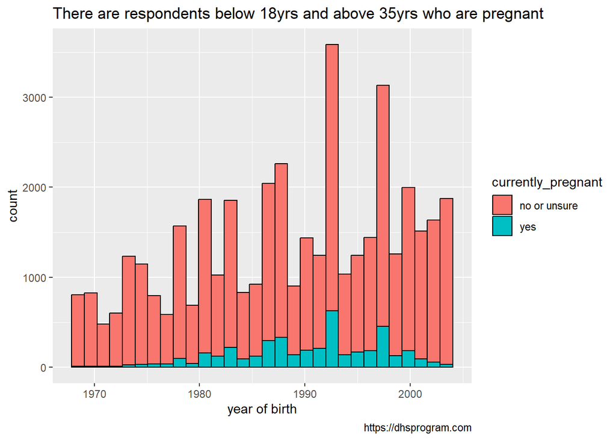

```r
ggplot(data = nigeria_clean,
 mapping = aes(x = yr_birth,
 fill = currently_pregnant)) +
 geom_histogram(color = "black",
 position = "stack") +
 labs(title = "There are respondents below 18yrs and above 35yrs who are pregnant",
 x = "year of birth",
 y = "count",
 caption = "https://dhsprogram.com")
```

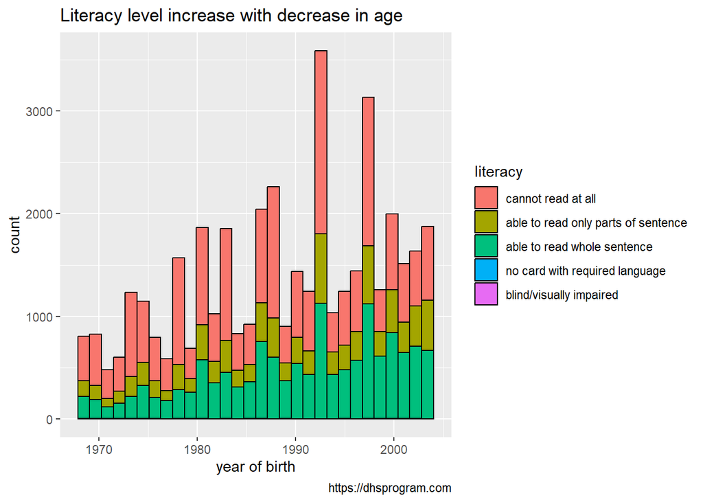

```r
ggplot(data = nigeria_clean,
 mapping = aes(x = yr_birth,
 fill = literacy)) +
 geom_histogram(color = "black",
 position = "stack") +
 labs(title = "Literacy level increase with decrease in age",
 x = "year of birth",
 y = "count",
 caption = "https://dhsprogram.com")
```

- 2.4 C) Identify the periods or locations in which the variables of interest showed significant increase, decrease or remained steady.

The variable of interest is the age of first birth and how it has been affected over the years due to various factors including government policy. We create a summary statistics on how the mean age of first birth has fluctuated over a period of a ten year interval.

```r
mean_age1 <- nigeria_clean %>%
 filter(yr_birth %in% c(1970, 1971, 1972, 1973, 1974, 1975, 1976,
 1977, 1978, 1979)) %>%
 summarise(mean_age_first_birth = round(mean(age_first_birth, na.rm = TRUE)))
```

The mean age at first birth in from the year 1970 to 1979 was 21 years.

```r
mean_age2 <- nigeria_clean %>%
 filter(yr_birth %in% c(1980, 1981, 1982, 1983, 1984, 1985,
 1986, 1987, 1988,1989)) %>%
 summarise(mean_age_first_birth = round(mean(age_first_birth, na.rm = TRUE)))
```

In the period between 1980 to 1989, the mean age for first birth was 20 years which was a marginal drop compared to the mean age for first birth between the year 1970 to 1979 which was 21 years.

```r
mean_age3 <- nigeria_clean %>%
 filter(yr_birth %in% c(1990, 1991, 1992, 1993, 1994,
 1995, 1996, 1997, 1998, 1999)) %>%
 summarise(mean_age_first_birth = round(mean(age_first_birth, na.rm = TRUE)))
```

In the period between 1990 to 1999, the mean age for first birth dropped drastically from 20 years for the years between 1980 to 1989 to 18 years for the years between 1990 to 1999.

```r
mean_age4 <-nigeria_clean%>%
 filter(yr_birth %in% c(2000, 2001,2002))%>%
 summarise(mean_age_first_birth= round(mean(age_first_birth, na.rm= TRUE)))
```

The mean age for first birth from the year 2000 to 2002 drops from 18 years for the years 1990 to 1999 to 16years.

```r
 mean_age5 <-nigeria_clean%>%
 filter(yr_birth ==2003)%>%
 summarise(mean_age_first_birth= round(mean(age_first_birth, na.rm= TRUE)))
```

For respondents born in the year 2003, the mean age at first birth is 14, which is a drastic drop from the previous years of 16.

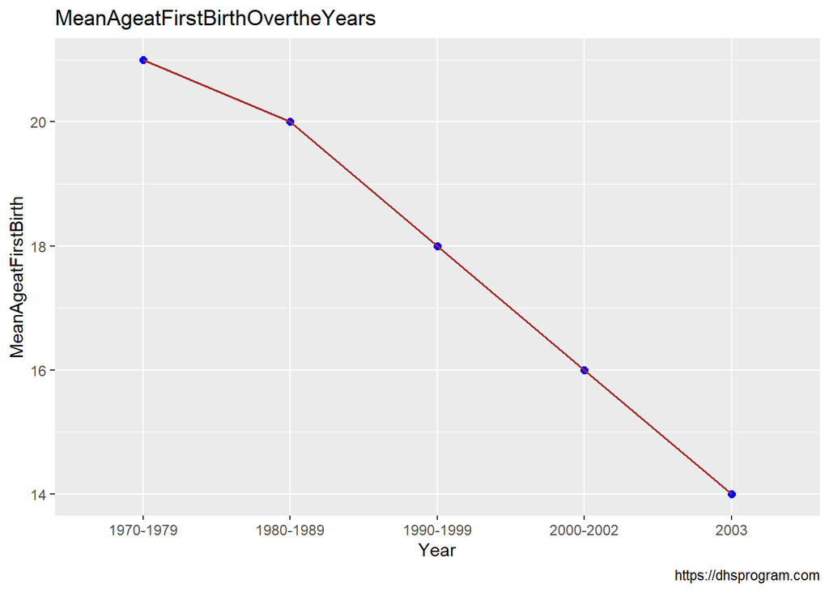

```r
#Combine the mean ages into a data frame
 mean_ages <- data.frame(
 Year= c("1970-1979", "1980-1989","1990-1999","2000-2002","2003"),
 Mean_Age_First_Birth= c(mean_age1$mean_age_first_birth,
                         mean_age2$mean_age_first_birth,
                         mean_age3$mean_age_first_birth,
                         mean_age4$mean_age_first_birth,
                         mean_age5$mean_age_first_birth)
 )

 #Create a line graph using ggplot2
 library(ggplot2)
 ggplot(mean_ages, aes(x= Year,y= Mean_Age_First_Birth,group= 1))+
 geom_point(size= 2,
 colour="blue") +
 geom_line(size= 0.7,
 color= "brown") +
 labs(title= "MeanAgeatFirstBirthOvertheYears",
 x= "Year",
 y= "MeanAgeatFirstBirth",
 caption= "https://dhsprogram.com")
```

- 2.4 D) Discuss the potential reasons for these trends based on your understanding or external research, form a hypothesis you might want to explore in the future.

Generally over the years, there has been a drop in the mean age at which the respondents in Nigeria have the first birth from a mean of 20.58 in the 70s to 14 in the year 2003. This can be attributed to a number of reasons such Economic conditions and access to opportunities. Economic instability, limited job prospects, and poverty can incentivize early childbearing, as young couples can perceive children as additional sources of support. Poor access to education is also a factor as girls who do not attend school or drop out early are more likely to have their first child at a young age than those who complete their education. Economic factors such as poverty can cause girls from poor households or communities to have limited access to reproductive health services, information, and contraception, which can increase their risk of unintended pregnancy and early childbearing. Some Nigerian communities may have traditions or beliefs that encourage or pressure girls to have children early, either for religious, economic, or social reasons. These norms may also discourage girls from using contraception or seeking abortion if they become pregnant before they are ready.

- Hypothesis.

The remarkable reduction in the mean age at first childbirth in Nigeria, signifying early childbearing among young individuals, may be attributed to a complex interplay of socioeconomic, cultural, educational, health care, policy, and societal factors. Future research should undertake a multifaceted investigation to quantify the specific contributions of these factors in driving the trend, explore regional variations within Nigeria, and identify potential intervention points to address early childbearing among the youth population.

## 3 Graded Task 3: Modelling

After diving into the data exploration, its time to operationalize our insights. This section requires you to decide on a dependent variable (Y) and an independent variable (X). Ensure that these variables are pertinent to your research questions.

### 3.1 Question 3.1

- what did you select as your independent and dependent variables.

My Dependent Variable (Y) for this analysis is the “num_kids” variable and the independent variable (X) for this analysis are: 1. “age_first_cohabitation”. 2. “age_first_birth”. 3. “listen_radio”. 4. “literacy”. 5. “religion”. 6. “highest_educ”.

- Explain the rationale behind your choice, how does these variables relate to or help answer your research questions?

The rationale behind selecting these independent variables is that they represent various factors that could potentially impact birth rates and, consequently, population growth. By analyzing these variables in relation to the number of children in a household, we can assess whether government policies aimed at reducing population growth have had an effect, and whether sociodemographic factors such as age at first cohabitation, age at first birth, exposure to public education through radio, literacy levels, religion, and education level play a role in influencing birth rates in Nigeria.

### 3.2 Question 3.2

How would you write out your regression formula for your Y and X variable.

Recall the regression formula 𝑌 −𝐵0+𝐵1+𝐶 where • 𝑌 is your expected/predicted outcome, if 𝑌 was wage then it would be expected_wage • 𝐵0 is the intercept. It represents the expected value of 𝑌 when X is 0 • 𝐵1 is the slope. It indicates the change in 𝑌 for a one unit change in X variable.

num_kids- 6.5304 + (-0.1342) + C ( for the “age_first_cohabitation” variable) Question 3.3) Now that you have written out your formula, program your regression in R and show your output using the summary function.

```r
 lm1 <- lm(formula = num_kids ~ age_first_cohabitation, data = nigeria_clean)
 lm2 <- lm(formula = num_kids ~ listen_radio, data = nigeria_clean)
 lm3 <- lm(formula = num_kids ~ literacy, data = nigeria_clean)
 lm4 <- lm(formula = num_kids ~ religion, data = nigeria_clean)
 lm5 <- lm(formula = num_kids ~ highest_educ, data = nigeria_clean)
```

We can now run the summary of each model.

```r
summary((lm1))
```

```
##
## Call:
## lm(formula = num_kids ~ age_first_cohabitation, data = nigeria_clean)
##
## Residuals:
##     Min      1Q  Median      3Q     Max
## -5.3226 -2.0542 -0.3703  1.6168 13.7639
##
## Coefficients:
##                         Estimate Std. Error t value Pr(>|t|)
## (Intercept)             6.530392   0.057573   113.4   <2e-16 ***
## age_first_cohabitation -0.134197   0.002996   -44.8   <2e-16 ***
## ---
## Signif. codes:  0 '***' 0.001 '**' 0.01 '*' 0.05 '.' 0.1 ' ' 1
##
## Residual standard error: 2.694 on 31150 degrees of freedom
##   (10669 observations deleted due to missingness)
## Multiple R-squared:  0.06053,    Adjusted R-squared:  0.0605
## F-statistic:  2007 on 1 and 31150 DF,  p-value: < 2.2e-16
```

The multiple R-squared value (0.06053) indicates the proportion of variability in the birth rate that can be explained by the age at first cohabitation. In this case, approximately 6.05% of the variability in birth rate is explained by this model. The F-statistic (2007) and its associated p-value (< 2.2e-16) test whether the overall model is statistically significant. In this case, the p-value is less than 0.05 suggests that the model as a whole is statistically significant. In summary, the “lm1” model suggests that there is a statistically significant negative relationship between the age at first cohabitation and the birth rate in Nigeria. As the age at first cohabitation decrease, the number of kids / birth rate tends to increase, while controlling for other factors in the model.

```r
summary(lm2)
```

```
##
## Call:
## lm(formula = num_kids ~ listen_radio, data = nigeria_clean)
##
## Residuals:
##     Min      1Q  Median      3Q     Max
## -3.2679 -2.8001 -0.8001  2.0682 14.0682
##
## Coefficients:
##                                   Estimate Std. Error t value Pr(>|t|)
## (Intercept)                        3.26788    0.02144 152.406   <2e-16 ***
## listen_radioless than once a week -0.46783    0.03554 -13.165   <2e-16 ***
## listen_radioat least once a week  -0.33608    0.03438  -9.776   <2e-16 ***
## ---
## Signif. codes:  0 '***' 0.001 '**' 0.01 '*' 0.05 '.' 0.1 ' ' 1
##
## Residual standard error: 2.95 on 41818 degrees of freedom
## Multiple R-squared:  0.004769,   Adjusted R-squared:  0.004722
## F-statistic: 100.2 on 2 and 41818 DF,  p-value: < 2.2e-16
```

```r
summary((lm3))
```

```
##
## Call:
## lm(formula = num_kids ~ literacy, data = nigeria_clean)
##
## Residuals:
##     Min      1Q  Median      3Q     Max
## -4.1798 -1.7143 -0.5991  1.8202 13.4009
##
## Coefficients:
##                                             Estimate Std. Error t value
## (Intercept)                                  4.17979    0.01949 214.511
## literacyable to read only parts of sentence -1.58074    0.03630 -43.547
## literacyable to read whole sentence         -2.46552    0.03025 -81.491
## literacyno card with required language      -1.84646    1.11858  -1.651
## literacyblind/visually impaired             -1.55817    0.45080  -3.456
##                                             Pr(>|t|)
## (Intercept)                                  < 2e-16 ***
## literacyable to read only parts of sentence  < 2e-16 ***
## literacyable to read whole sentence          < 2e-16 ***
## literacyno card with required language      0.098803 .
## literacyblind/visually impaired             0.000548 ***
## ---
## Signif. codes:  0 '***' 0.001 '**' 0.01 '*' 0.05 '.' 0.1 ' ' 1
##
## Residual standard error: 2.74 on 41816 degrees of freedom
## Multiple R-squared:  0.1418, Adjusted R-squared:  0.1417
## F-statistic:  1728 on 4 and 41816 DF,  p-value: < 2.2e-16
```

The multiple R-squared value (0.1418) indicates the proportion of variability in the birth rate that can be explained by the literacy levels. In this case, approximately 14.18% of the variability in birth rates is explained by this model. The F-statistic (1728) and its associated p-value (< 2.2e-16) which is also less than 0.05 shows that the model as a whole is highly statistically significant. In summary, the “lm3” model suggests that there is a statistically significant relationship between literacy levels and the birth rate in Nigeria. As individuals’ literacy levels decrease, the birth rate tends to increase, holding other factors constant.

```r
summary(lm4)
```

```
##
## Call:
## lm(formula = num_kids ~ religion, data = nigeria_clean)
##
## Residuals:
##     Min      1Q  Median      3Q     Max
## -4.3397 -2.4465 -0.5101  1.5535 13.3766
##
## Coefficients:
##                         Estimate Std. Error t value Pr(>|t|)
## (Intercept)              2.51014    0.04352  57.679  < 2e-16 ***
## religionother christian -0.06360    0.04916  -1.294    0.196
## religionislam            1.11322    0.04790  23.239  < 2e-16 ***
## religiontraditionalist   1.82960    0.23611   7.749 9.48e-15 ***
## religionother           -0.13514    0.20952  -0.645    0.519
## ---
## Signif. codes:  0 '***' 0.001 '**' 0.01 '*' 0.05 '.' 0.1 ' ' 1
##
## Residual standard error: 2.898 on 41816 degrees of freedom
## Multiple R-squared:  0.03934,    Adjusted R-squared:  0.03925
## F-statistic: 428.1 on 4 and 41816 DF,  p-value: < 2.2e-16
```

The multiple R-squared value (0.03934) indicates the proportion of variability in the birth rate that can be explained by individuals’ religious affiliation (religion variable). In this case, approximately 3.93% of the variability in birth rates is explained by this model. The F-statistic (428.1) and its associated p-value of (< 2.2e-16) which is less than 0.05 shows that the model as a whole is highly statistically significant. In summary, the “lm4” model suggests that there is a statistically significant relationship between individuals’ religious affiliation and the birth rate in Nigeria. The type of religion individuals identify with is associated with differences in birth rates, with “islam” and “traditionalist” categories being associated with higher birth rates compared to the reference category.

### 3.3 Question 3.3

Now time to program a multi-variate regression using an additional X. I dentify a second X that you want to include and,

2. ) Re-run your regression including your new X and provide an interpretation of your outcomes, include a statistical interpretation on your model model fit.

```r
lm6 <- lm(formula = num_kids ~ age_first_cohabitation + highest_educ, data = nigeria_clean)
```

```r
summary(lm6)
```

```
##
## Call:
## lm(formula = num_kids ~ age_first_cohabitation + highest_educ,
##     data = nigeria_clean)
##
## Residuals:
##     Min      1Q  Median      3Q     Max
## -5.3334 -1.9126 -0.2313  1.6569 12.4977
##
## Coefficients:
##                         Estimate Std. Error t value Pr(>|t|)
## (Intercept)             6.049976   0.058676 103.108   <2e-16 ***
## age_first_cohabitation -0.079615   0.003336 -23.866   <2e-16 ***
## highest_educprimary    -0.022782   0.042819  -0.532    0.595
## highest_educsecondary  -1.305965   0.037867 -34.488   <2e-16 ***
## highest_educhigher     -1.397988   0.060553 -23.087   <2e-16 ***
## ---
## Signif. codes:  0 '***' 0.001 '**' 0.01 '*' 0.05 '.' 0.1 ' ' 1
##
## Residual standard error: 2.631 on 31147 degrees of freedom
##   (10669 observations deleted due to missingness)
## Multiple R-squared:  0.1046, Adjusted R-squared:  0.1045
## F-statistic: 909.7 on 4 and 31147 DF,  p-value: < 2.2e-16
```

Multiple R-squared (0.1046) represents the proportion of variance in the dependent variable explained by the model. Adjusted R-squared (0.1045) adjusts for the number of predictors in the model. This statistic tests the overall significance of the model. In this case, the F-statistic is 909.7 with a very low p-value (<2.2e-16) less than 0.05, indicates that the model as a whole is statistically significant. Overall, this regression model suggests that age_first_cohabitation and the level of education (highest_educ) are associated with changes in birth_rate, with individuals whose age at first cohabitation higher and have secondary or higher education having lower birth rates. Extra Credit Question 3.6) Now we ask that you take your regression outputs and improve their readabilty by using arguments in the stargaze package, include both models. ( Hint: I showed this package in week 5, see the rmd file ). Please note the” result as is ” chunk option and you will see the pretty table in the final knitted PDF and not in the chunk output. Your model name should be according to what they are for example, BI-variate or Multi-variate, dive into the stargazer documentation to make it as nice as possible.

```r
if(!require(pacman)) install.packages("pacman")
pacman::p_load(stargazer)
```

```r
# Create a list of models with names
 my_models <- list(
   "Bivariate Model4" = lm4,
   "Multivariate Model6" = lm6
 )
 # Generate the table with named models
 stargazer::stargazer(my_models,
 title = "2 Binary Models",
 type = "text",
 keep.stat = c("n", "rsq", "f"),
 column.labels = c("Bivariate Model4", "Multivariate Model6"),
 header = FALSE) # Prevents the addition of LaTeX headers
```

```
##
## 2 Binary Models
## =============================================================================
##                                          Dependent variable:
##                         -----------------------------------------------------
##                                               num_kids
##                              Bivariate Model4         Multivariate Model6
##                                    (1)                        (2)
## -----------------------------------------------------------------------------
## religionother christian           -0.064
##                                  (0.049)
##
## religionislam                    1.113***
##                                  (0.048)
##
## religiontraditionalist           1.830***
##                                  (0.236)
##
## religionother                     -0.135
##                                  (0.210)
##
## age_first_cohabitation                                     -0.080***
##                                                             (0.003)
##
## highest_educprimary                                          -0.023
##                                                             (0.043)
##
## highest_educsecondary                                      -1.306***
##                                                             (0.038)
##
## highest_educhigher                                         -1.398***
##                                                             (0.061)
##
## Constant                         2.510***                   6.050***
##                                  (0.044)                    (0.059)
##
## -----------------------------------------------------------------------------
## Observations                      41,821                     31,152
## R2                                0.039                      0.105
## F Statistic             428.075*** (df = 4; 41816) 909.658*** (df = 4; 31147)
## =============================================================================
## Note:                                             *p<0.1; **p<0.05; ***p<0.01
```

**HWExtra Credit: Fixed Effects** Gain some extra points by delving into the world of regression modelling. Note: Accurately answering each question will earn you 1 point returned on a previous homework of your choice. Please specify the homework assignment where you’d like the point to be added.

**EC Question 1)** As mentioned, pick a time or spacial element you want to control for in your regression analysis. This is often important in empirical research to capture unobserved heterogenity. • Which specific element ( e.g., year, region, etc) did you choose for and why?

Controlling for the “region” is an appropriate choice in regression analysis, as it can help capture spatial variations and unobserved heterogeneity in the data. By including “region” as a fixed effect, we can account for differences in outcomes that might be specific to different regions. This can be important, especially in the context of government policies and their impact on population growth, as regions may have distinct policy implementations or social and economic characteristics.

The “region” variable could confound the relationship between the dependent variable (e.g Number of children) and the independent variable (e.g., age at first cohabitation) because different regions may have varying cultural, economic, and social factors that influence birth rates differently. For example, one region might have a higher literacy rate and better access to family planning services, resulting in lower birth rates, while another region might have different cultural norms or economic conditions that lead to higher birth rates. By including “region” as a fixed effect, we control for these unobserved regional variations, making the analysis more robust and allowing us to focus on the specific impact of the independent variable on the dependent variable across regions. • How might this element confound the relationship between your department and independent variable?

Regions can have unique characteristics, policies, and cultural factors that influence both the dependent and independent variables differently. For example, a region with strong family planning initiatives may have a lower birth rate, which can confound the relationship between the age at first cohabitation and number of kids. The effect of age at first cohabitation on birth rate may differ across regions. Again, Including “region” as a fixed effect may introduce multicollinearity into the regression model. Multicollinearity occurs when two or more independent variables are highly correlated, making it challenging to discern the individual effects of each variable. If the region has a strong influence on both the dependent and independent variables, it can lead to multicollinearity and make it difficult to isolate the specific impact of the independent variable.

**EQ Question 2)**

Fixed effects can be used to control for time invariant unobserved heterogenity. Implement a fixed- effects regression in R, controlling for the element you selected in EC Question 1. Show your code and output using summary() function.

```r
 # Load the plm package
 if (!require("pacman")) install.packages("pacman")
pacman::p_load(plm)
```

```r
# Create a panel data frame with fixed effects
panel_data <- pdata.frame(nigeria_clean, index = c("region"))
 # Run a fixed-effects regression
 lm7 <- plm(num_kids ~ age_first_cohabitation + highest_educ, data = panel_data, model = "within")
 # Summarize the model
 summary(lm7)
```

```
## Oneway (individual) effect Within Model
##
## Call:
## plm(formula = num_kids ~ age_first_cohabitation + highest_educ,
##     data = panel_data, model = "within")
##
## Unbalanced Panel: n = 6, T = 3364-8433, N = 31152
##
## Residuals:
##     Min.  1st Qu.   Median  3rd Qu.     Max.
## -5.49738 -1.90087 -0.20661  1.66669 12.38951
##
## Coefficients:
##                          Estimate Std. Error t-value Pr(>|t|)
## age_first_cohabitation -0.0820391  0.0034873 -23.525   <2e-16 ***
## highest_educprimary    -0.0411549  0.0457261  -0.900   0.3681
## highest_educsecondary  -1.3415805  0.0428320 -31.322   <2e-16 ***
## highest_educhigher     -1.3953137  0.0626312 -22.278   <2e-16 ***
## ---
## Signif. codes:  0 '***' 0.001 '**' 0.01 '*' 0.05 '.' 0.1 ' ' 1
##
## Total Sum of Squares:    232210
## Residual Sum of Squares: 214300
## R-Squared:      0.077145
## Adj. R-Squared: 0.076879
## F-statistic: 650.824 on 4 and 31142 DF, p-value: < 2.22e-16
```

**EC Question 3**

```r
#Create a listofmodelswithnames
 my_models <-list(
 "BivariateModel4" = lm4,
 "MultivariateModel6" = lm6,
 "fixed_model"= lm7
 )
 #Generate thetablewithnamedmodels
 stargazer::stargazer(my_models,
 title= "2BinaryModels",
 type= "text",
 keep.stat= c("n","rsq", "f"),
 column.labels = c("BivariateModel4", "MultivariateModel6", "fixedeffects"),
 header= FALSE) #PreventstheadditionofLaTeXheaders
```

```
##
## 2BinaryModels
## ========================================================================================================
##                                                       Dependent variable:
##                         --------------------------------------------------------------------------------
##                                                             num_kids
##                                                  OLS                                    panel
##                                                                                         linear
##                              BivariateModel4           MultivariateModel6            fixedeffects
##                                    (1)                        (2)                        (3)
## --------------------------------------------------------------------------------------------------------
## religionother christian           -0.064
##                                  (0.049)
##
## religionislam                    1.113***
##                                  (0.048)
##
## religiontraditionalist           1.830***
##                                  (0.236)
##
## religionother                     -0.135
##                                  (0.210)
##
## age_first_cohabitation                                     -0.080***                  -0.082***
##                                                             (0.003)                    (0.003)
##
## highest_educprimary                                          -0.023                     -0.041
##                                                             (0.043)                    (0.046)
##
## highest_educsecondary                                      -1.306***                  -1.342***
##                                                             (0.038)                    (0.043)
##
## highest_educhigher                                         -1.398***                  -1.395***
##                                                             (0.061)                    (0.063)
##
## Constant                         2.510***                   6.050***
##                                  (0.044)                    (0.059)
##
## --------------------------------------------------------------------------------------------------------
## Observations                      41,821                     31,152                     31,152
## R2                                0.039                      0.105                      0.077
## F Statistic             428.075*** (df = 4; 41816) 909.658*** (df = 4; 31147) 650.824*** (df = 4; 31142)
## ========================================================================================================
## Note:                                                                        *p<0.1; **p<0.05; ***p<0.01
```

**EC Question 4)** Compare the results of this fixed effects regression with your previous multivariate regression.

- Have the co-efficients on your main variable of interest changed significantly?

The coefficient for “age_first_cohabitation” has changed slightly from-0.079615 in the multivariate regression to-0.0820391 in the fixed-effects regression. While this change is relatively small, it indicates that accounting for the region as a fixed effect may have a slight influence on the relationship between age at first cohabitation and the number of children. This could be due to regional variations in unobserved factors that affect the dependent variable.

- What can you infer about the potential confounding influence of the time or spacial element you controlled for?

The inclusion of “region” as a fixed effect in the fixed-effects regression is intended to control for spatial variations. This means that we are accounting for differences in outcomes that may be specific to different regions. The slightly different coefficient for “age_first_cohabitation” in the fixed-effects regression suggests that regional differences may indeed influence the relationship between age at first cohabitation and the number of children. While controlling for region helps reduce spatial confounding, there might still be unobserved regional specific factors affecting the relationship. It is essential to acknowledge that even after using fixed effects, unobserved confounding variables related to both time and space may persist, but the model has become more robust by accounting for region-specific variations.

**References**

- Okpala, A. O. (1990). Nigerian population growth and its implications for economic development. Scandinavian Journal of Development Alternatives, 9(4), 63-77.
- Mazzocco, K. (1988). Nigeria’s new population policy. International health news, 9(3), 1-12.
- https://dailypost.ng/2021/05/14/fg-must-take-urgent-steps-to-address-rapid-population-growth health-minister-osagie-ehanire/
- https://dhsprogram.com/data/new-user-registration.cfm